# Dictionaries and an example of a supervised classifier

20 April 2018

This document describes dictionary methods and supervised machine learning methods for classifying UK prime minister speeches. Let’s take a look a set of UK prime minister speeches from the [EUSpeech](https://dataverse.harvard.edu/dataverse/euspeech) dataset. NB: Use setwd() to set the working directory to the folder that contains English speeches in the file speeches_uk.csv.

```r
Sys.setlocale(locale = "en_US.UTF-8")
```

```
## [1] "en_US.UTF-8/en_US.UTF-8/en_US.UTF-8/C/en_US.UTF-8/C"
```

```r
#load libraries
library(readtext)
library(quanteda)

#read in speeches
speeches <- readtext("speeches_uk.csv", text_field = "text", encoding = "UTF-8")
#remove p tags
speeches$text <- gsub("<.*?>", "", speeches$text)
#construct a corpus
corpus <- corpus(speeches)
#focus on Cameron and Brown
corpus <- corpus_subset(corpus, speaker != "T. Blair")
#turn the date variable in a date format instead of character format
docvars(corpus, "date") <- as.Date(docvars(corpus, "date"), "%d-%m-%Y")

#turn this into a dfm
corpus.dfm <- dfm(corpus, stem = FALSE, remove=stopwords("english"), remove_punct=TRUE)
dim(corpus.dfm)
```

```
## [1]   776 43954
```

```r
#trim this corpus to speed up calculations
corpus.dfm = dfm_trim(corpus.dfm, min_docfreq = 20)
dim(corpus.dfm)
```

```
## [1]  776 3907
```

## Dictionary methods

When working with your own dictionary, most of the work will go into development in order to make sure that it captures the construct that you are looking for. However, once you have your dictionary, it is very easy in `quanteda` to apply it to a corpus. Let’s say where are interested in how often Cameron and Brown mention immigration, refugees and asylum:

```r
#create a dictionary
practice.dict <- dictionary(list(Immigration = c("immi*"),
                                 Refugees = c("refug*"),
                                 Asylum = c("asyl*")))

practice.dict.dfm <- dfm(corpus.dfm, dictionary = practice.dict)

dim(practice.dict.dfm)
```

```
## [1] 776   3
```

```r
head(practice.dict.dfm)
```

```
## Document-feature matrix of: 6 documents, 3 features (88.9% sparse).
## 6 x 3 sparse Matrix of class "dfm"
##        features
## docs    Immigration Refugees Asylum
##   text1           0        3      0
##   text2           0        0      0
##   text3           0        0      0
##   text4           0        0      0
##   text5           0        1      0
##   text6           0        0      0
```

`Quanteda` contains a few off-the-shelf dictionaries . Let’s take a look at the Lexicoder Sentiment Dictionary from Young and Soroka (2012). It’s stored in `quanteda` as a dictionary object under `data_dictionary_LSD2015`. Let’s use it on the Cameron speeches

```r
#create Cameron corpus and dfm
corpus.cameron <- corpus_subset(corpus, speaker == "D. Cameron")
corpus.cameron.dfm <- dfm(corpus.cameron, stem = FALSE, remove=stopwords("english"), remove_punct=TRUE)
corpus.cameron.dfm = dfm_trim(corpus.cameron.dfm, min_docfreq = 20)

#look at the Lexicoder Sentiment Dictionary in quanteda
str(data_dictionary_LSD2015)
```

```
## Formal class 'dictionary2' [package "quanteda"] with 2 slots
##   ..@ .Data       :List of 4
##   .. ..$ :List of 1
##   .. .. ..$ : chr [1:2858] "a lie" "abandon*" "abas*" "abattoir*" ...
##   .. ..$ :List of 1
##   .. .. ..$ : chr [1:1709] "ability*" "abound*" "absolv*" "absorbent*" ...
##   .. ..$ :List of 1
##   .. .. ..$ : chr [1:1721] "best not" "better not" "no damag*" "no no" ...
##   .. ..$ :List of 1
##   .. .. ..$ : chr [1:2860] "not a lie" "not abandon*" "not abas*" "not abattoir*" ...
##   ..@ concatenator: chr " "
```

```r
#create a dfm of dictionary words found in the Cameron corpus
sentiment.dfm <- dfm(corpus.cameron.dfm, dictionary = data_dictionary_LSD2015)
dim(sentiment.dfm)
```

```
## [1] 493   4
```

```r
head(sentiment.dfm)
```

```
## Document-feature matrix of: 6 documents, 4 features (50% sparse).
## 6 x 4 sparse Matrix of class "dfm"
##        features
## docs    negative positive neg_positive neg_negative
##   text1       45      134            0            0
##   text2       10       46            0            0
##   text3        6       47            0            0
##   text4       61      250            0            0
##   text5       10       46            0            0
##   text6       32       18            0            0
```

We can calculate the proportion of negative sentiment words and positive sentiment words in each speech (NB: we only focus on the negative sentiment words and not on the negations of positive sentiment words), and we’ll save those as variables in docvars.

```r
#proportion of negative words
docvars(corpus.cameron.dfm, "prop.neg.words") <- as.numeric(sentiment.dfm[,1] / ntoken(corpus.cameron.dfm))

#proportion of positive words
docvars(corpus.cameron.dfm, "prop.pos.words") <- as.numeric(sentiment.dfm[,2] / ntoken(corpus.cameron.dfm))

#net sentiment
docvars(corpus.cameron.dfm, "net.sentiment")  <- docvars(corpus.cameron.dfm, "prop.pos.words") - docvars(corpus.cameron.dfm, "prop.neg.words")
```

Did the net sentiment of Cameron speeches change over time? Let’s plot to find out.

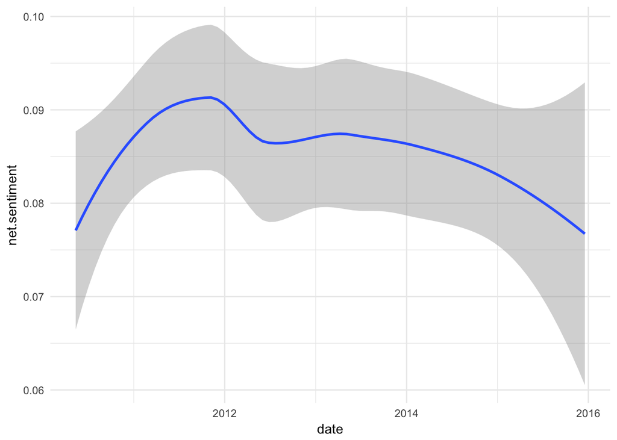

```r
library(ggplot2)

sentiment.plot <- ggplot(docvars(corpus.cameron.dfm), aes(x = date, y = net.sentiment))
sentiment.plot  <- sentiment.plot  + geom_smooth() + theme_minimal()
print(sentiment.plot)
```

Answer: not really.

For more off-the-shelve dictionaries take a look at the `tidytext` library. `quanteda` can read those in as well.

## Supervised machine learning

Perhaps there is something intrinsically different about how Cameron and Brown speak. Let’s see if we build a classifier to predict if a speech is delivered by Cameron or Brown. First, take out a training set and a test from the corpus. The `set.seed()` function makes sure that you can replicate your random samples:

```r
set.seed(2)

#random subset of 100 speeches of the corpus
corpus.dfm <- dfm_sample(corpus.dfm, replace = FALSE, size = 100)
dim(corpus.dfm)
```

```
## [1]  100 3907
```

```r
#take note of how many speeches by Cameron and Brown
table(docvars(corpus.dfm, "speaker"))
```

```
##
## D. Cameron   G. Brown
##         65         35
```

```r
#take a sample of 60 speeches as our training data
train_dfm <- dfm_sample(corpus.dfm, size = 60)

#and the 40 remaining speeches as our test data: the code within the which() function says `take the docs from the corpus which are *not* present in train_dfm.
test_dfm <- dfm_subset(corpus.dfm, which(!(docnames(corpus.dfm)  %in% docnames(train_dfm))))
```

We can now train a Naive Bayes classifier to analyze if we can predict whether a speech in the test set is from Cameron or Brown.

```r
speaker.classifier <- textmodel_nb(train_dfm, y = docvars(train_dfm, "speaker"))
pred.speaker.classifier <- predict(speaker.classifier, newdata = test_dfm)

table(predicted.speaker = pred.speaker.classifier$nb.predicted, actual.speaker = docvars(test_dfm, "speaker"))
```

```
##                  actual.speaker
## predicted.speaker D. Cameron G. Brown
##        D. Cameron         27        2
##        G. Brown            0       11
```

So it appears we are quite successful at predicting whether a speech is delivered by Cameron or Brown. Using the descriptive text statistics we discussed in class we can figure out which features distinguish between both speakers. We can then apply this classifier to the other speeches.